# JSC370 Homework 2 - Yibing Xia

Author

Yibing Xia

```python
import pandas as pd
import numpy as np
from plotnine import *
import warnings
warnings.filterwarnings('ignore')
import requests
from bs4 import BeautifulSoup
from io import StringIO
import statsmodels.api as sm
from pygam import LinearGAM, s, l
import matplotlib.pyplot as plt
from IPython.display import display
```

# Research Questions

- Is there an association between life expectancy and alcohol consumption?
- How have life expectancy and alcohol consumption changed over time?
- Do other country specific factors such as per capita gross domestic product or population play a role in the relationship between alcohol consumption and life expectancy?

# Data Acquisition and Wrangling

## Question 1 (15 points)

### 1a. World Bank API Data

#### Fetch from API

```python
# Fetch life expectancy (SP.DYN.LE00.IN), population (SP.POP.TOTL),
# and GDP per capita (NY.GDP.PCAP.CD) from World Bank API

base_url = "http://api.worldbank.org/v2/country/all/indicator/"

indicators = {
    'life_expectancy': 'SP.DYN.LE00.IN',
    'population': 'SP.POP.TOTL',
    'gdp_per_capita': 'NY.GDP.PCAP.CD'
}

# Years of interest
years = "1996:2019"

# Fetch data for each indicator
raw_data = {}
for name, code in indicators.items():
    url = f"{base_url}{code}?format=json&date={years}&per_page=20000"
    response = requests.get(url)
    raw_data[name] = response.json()
    print(f"Fetched {name}: {len(raw_data[name])} elements")
```

```
Fetched life_expectancy: 2 elements
Fetched population: 2 elements
Fetched gdp_per_capita: 2 elements
```

#### Parse and Clean

```python
# Parse nested JSON responses into clean DataFrames for each indicator
dfs = {}
for name, json_data in raw_data.items():
    # API returns [metadata, data_array], want the data_array
    data_array = json_data[1]
    df = pd.DataFrame(data_array)

    df_clean = pd.DataFrame({
        'country': df['country'].apply(lambda x: x['value']),
        'country_code': df['countryiso3code'],
        'year': df['date'].astype(int),
        'value': df['value']
    })

    dfs[name] = df_clean
    print(f"\n{name} - Shape: {df_clean.shape}")
    display(df_clean.head())
```

```
life_expectancy - Shape: (6384, 4)
```

|  | country | country_code | year | value |
| --- | --- | --- | --- | --- |
| 0 | Africa Eastern and Southern | AFE | 2019 | 63.857261 |
| 1 | Africa Eastern and Southern | AFE | 2018 | 63.330691 |
| 2 | Africa Eastern and Southern | AFE | 2017 | 62.591275 |
| 3 | Africa Eastern and Southern | AFE | 2016 | 62.167981 |
| 4 | Africa Eastern and Southern | AFE | 2015 | 61.713031 |

```
population - Shape: (6384, 4)
```

|  | country | country_code | year | value |
| --- | --- | --- | --- | --- |
| 0 | Africa Eastern and Southern | AFE | 2019 | 675950189.0 |
| 1 | Africa Eastern and Southern | AFE | 2018 | 657801085.0 |
| 2 | Africa Eastern and Southern | AFE | 2017 | 640058741.0 |
| 3 | Africa Eastern and Southern | AFE | 2016 | 623369401.0 |
| 4 | Africa Eastern and Southern | AFE | 2015 | 607123269.0 |

```
gdp_per_capita - Shape: (6384, 4)
```

|  | country | country_code | year | value |
| --- | --- | --- | --- | --- |
| 0 | Africa Eastern and Southern | AFE | 2019 | 1507.085600 |
| 1 | Africa Eastern and Southern | AFE | 2018 | 1552.073722 |
| 2 | Africa Eastern and Southern | AFE | 2017 | 1528.104224 |
| 3 | Africa Eastern and Southern | AFE | 2016 | 1334.470500 |
| 4 | Africa Eastern and Southern | AFE | 2015 | 1498.875240 |

#### Filter Countries and Years

```python
# Fetch country list
country_url = "http://api.worldbank.org/v2/country?format=json&per_page=500"
country_data = requests.get(country_url).json()[1]

# Get ISO3 codes for actual countries (exclude aggregates)
country_iso3 = [c['id'] for c in country_data if c['region']['value'] != 'Aggregates']
print(f"Found {len(country_iso3)} countries")

# Filter each indicator to countries only
for name in dfs.keys():
    before = len(dfs[name])
    dfs[name] = dfs[name][dfs[name]['country_code'].isin(country_iso3)]
    after = len(dfs[name])
    print(f"{name}: {after} records (filtered from {before})")
```

```
Found 217 countries
life_expectancy: 5208 records (filtered from 6384)
population: 5208 records (filtered from 6384)
gdp_per_capita: 5208 records (filtered from 6384)
```

```python
# Filter to years 1996, 2016, 2019
target_years = [1996, 2016, 2019]

for name in dfs.keys():
    print(f"\n{name}:")
    display(dfs[name].shape)
    print(f"  Years before: {sorted(dfs[name]['year'].unique())}")
    dfs[name] = dfs[name][dfs[name]['year'].isin(target_years)]
    print(f"  Years after: {sorted(dfs[name]['year'].unique())}")
    display(dfs[name].head())
```

```
life_expectancy:
```

```
(5208, 4)
```

```
  Years before: [1996, 1997, 1998, 1999, 2000, 2001, 2002, 2003, 2004, 2005, 2006, 2007, 2008, 2009, 2010, 2011, 2012, 2013, 2014, 2015, 2016, 2017, 2018, 2019]
  Years after: [1996, 2016, 2019]
```

|  | country | country_code | year | value |
| --- | --- | --- | --- | --- |
| 1176 | Afghanistan | AFG | 2019 | 62.941 |
| 1179 | Afghanistan | AFG | 2016 | 62.646 |
| 1199 | Afghanistan | AFG | 1996 | 52.830 |
| 1200 | Albania | ALB | 2019 | 79.467 |
| 1203 | Albania | ALB | 2016 | 78.643 |

```
population:
```

```
(5208, 4)
```

```
  Years before: [1996, 1997, 1998, 1999, 2000, 2001, 2002, 2003, 2004, 2005, 2006, 2007, 2008, 2009, 2010, 2011, 2012, 2013, 2014, 2015, 2016, 2017, 2018, 2019]
  Years after: [1996, 2016, 2019]
```

|  | country | country_code | year | value |
| --- | --- | --- | --- | --- |
| 1176 | Afghanistan | AFG | 2019 | 37856121.0 |
| 1179 | Afghanistan | AFG | 2016 | 34700612.0 |
| 1199 | Afghanistan | AFG | 1996 | 17763266.0 |
| 1200 | Albania | ALB | 2019 | 2567801.0 |
| 1203 | Albania | ALB | 2016 | 2689469.0 |

```
gdp_per_capita:
```

```
(5208, 4)
```

```
  Years before: [1996, 1997, 1998, 1999, 2000, 2001, 2002, 2003, 2004, 2005, 2006, 2007, 2008, 2009, 2010, 2011, 2012, 2013, 2014, 2015, 2016, 2017, 2018, 2019]
  Years after: [1996, 2016, 2019]
```

|  | country | country_code | year | value |
| --- | --- | --- | --- | --- |
| 1176 | Afghanistan | AFG | 2019 | 496.602504 |
| 1179 | Afghanistan | AFG | 2016 | 522.082216 |
| 1199 | Afghanistan | AFG | 1996 | NaN |
| 1200 | Albania | ALB | 2019 | 6069.439031 |
| 1203 | Albania | ALB | 2016 | 4457.634122 |

#### Merge Indicators

```python
# Extract and rename value columns for each indicator
life_exp_df = dfs['life_expectancy'].rename(columns={'value': 'life_expectancy'})
pop_df = dfs['population'].rename(columns={'value': 'population'})
gdp_df = dfs['gdp_per_capita'].rename(columns={'value': 'gdp_per_capita'})

# Merge by country and year
wb = life_exp_df.merge(pop_df, on=['country', 'country_code', 'year'])
wb = wb.merge(gdp_df, on=['country', 'country_code', 'year'])

print(f"Merged World Bank data: {wb.shape}")
display(wb.head())
display(wb.info())
```

```
Merged World Bank data: (651, 6)
```

|  | country | country_code | year | life_expectancy | population | gdp_per_capita |
| --- | --- | --- | --- | --- | --- | --- |
| 0 | Afghanistan | AFG | 2019 | 62.941 | 37856121.0 | 496.602504 |
| 1 | Afghanistan | AFG | 2016 | 62.646 | 34700612.0 | 522.082216 |
| 2 | Afghanistan | AFG | 1996 | 52.830 | 17763266.0 | NaN |
| 3 | Albania | ALB | 2019 | 79.467 | 2567801.0 | 6069.439031 |
| 4 | Albania | ALB | 2016 | 78.643 | 2689469.0 | 4457.634122 |

```
<class 'pandas.core.frame.DataFrame'>
RangeIndex: 651 entries, 0 to 650
Data columns (total 6 columns):
 #   Column           Non-Null Count  Dtype
---  ------           --------------  -----
 0   country          651 non-null    object
 1   country_code     651 non-null    object
 2   year             651 non-null    int64
 3   life_expectancy  651 non-null    float64
 4   population       651 non-null    float64
 5   gdp_per_capita   621 non-null    float64
dtypes: float64(3), int64(1), object(2)
memory usage: 30.6+ KB
```

```
None
```

### 1b. Alcohol Consumption (Web Scraping)

#### Scrape Wikipedia

```python
# Scrape Wikipedia alcohol consumption page
ALCOHOL_URL = "https://en.wikipedia.org/wiki/List_of_countries_by_alcohol_consumption_per_capita"
HEADERS = {
    "User-Agent": "jsc370-homework/1.0 (educational use)",
    "Accept-Language": "en-US,en;q=0.9",
}

alcohol_response = requests.get(ALCOHOL_URL, headers=HEADERS, timeout=30)
print(f"Status code: {alcohol_response.status_code}")

alcohol_tables = pd.read_html(StringIO(alcohol_response.text))
print(f"Found {len(alcohol_tables)} tables")

# Extract the second table which contains historical consumption data
alcohol = alcohol_tables[1]
print(f"\nHistorical consumption table: {alcohol.shape}")
display(alcohol.head())
display(alcohol.columns)
```

```
Status code: 200
Found 15 tables

Historical consumption table: (191, 4)
```

|  | Country | 1996[9] | 2016[10] | 2019[6][a] |
| --- | --- | --- | --- | --- |
| 0 | Afghanistan | – | 0.2 | 0.2 |
| 1 | Albania | 2.59 | 7.5 | 5.1 |
| 2 | Algeria | 0.27 | 0.9 | 0.6 |
| 3 | Andorra | – | 11.3 | 11.1 |
| 4 | Angola | 1.58 | 6.4 | 6.2 |

```
Index(['Country', '1996[9]', '2016[10]', '2019[6][a]'], dtype='object')
```

#### Clean Scraped Data

```python
# Remove footnote markers in column names
alcohol.columns = alcohol.columns.str.replace(r'\[.*?\]', '', regex=True)
# Remove footnote markers from data cells
alcohol = alcohol.replace(r'\[.*?\]', '', regex=True)

print(f"Columns: {alcohol.columns.tolist()}")
display(alcohol.head())
```

```
Columns: ['Country', '1996', '2016', '2019']
```

|  | Country | 1996 | 2016 | 2019 |
| --- | --- | --- | --- | --- |
| 0 | Afghanistan | – | 0.2 | 0.2 |
| 1 | Albania | 2.59 | 7.5 | 5.1 |
| 2 | Algeria | 0.27 | 0.9 | 0.6 |
| 3 | Andorra | – | 11.3 | 11.1 |
| 4 | Angola | 1.58 | 6.4 | 6.2 |

```python
# Check unique values in year columns
year_cols = ['1996', '2016', '2019']
for col in year_cols:
    print(f"\n{col} first 10 unique values:")
    display(alcohol[col].unique()[:10])

# Convert year columns to numeric
for col in year_cols:
    alcohol[col] = pd.to_numeric(alcohol[col].replace('–', np.nan), errors='coerce')

print("\nAfter converting:")
display(alcohol.dtypes)
```

```
1996 first 10 unique values:
```

```
array(['–', '2.59', '0.27', '1.58', '9.58', '0.84', '9.55', '11.90',
       '4.16', '8.37'], dtype=object)
```

```
2016 first 10 unique values:
```

```
array(['0.2', '7.5', '0.9', '11.3', '6.4', '7.0', '9.8', '5.5', '10.6',
       '11.6'], dtype=object)
```

```
2019 first 10 unique values:
```

```
array(['0.2', '5.1', '0.6', '11.1', '6.2', '8.5', '8.0', '5.0', '10.1',
       '12.0'], dtype=object)
```

```
After converting:
```

```
Country     object
1996       float64
2016       float64
2019       float64
dtype: object
```

```python
print("Missing values per column:")
display(alcohol.isnull().sum())

# Drop rows where all year columns are NaN
# Keep rows with some NaN values which will be handled during merging
alcohol = alcohol.dropna(subset=year_cols, how='all')

print(f"\nAfter dropping rows with no data: {alcohol.shape}")
display(alcohol.head())
```

```
Missing values per column:
```

```
Country     0
1996       43
2016        2
2019        2
dtype: int64
```

```
After dropping rows with no data: (191, 4)
```

|  | Country | 1996 | 2016 | 2019 |
| --- | --- | --- | --- | --- |
| 0 | Afghanistan | NaN | 0.2 | 0.2 |
| 1 | Albania | 2.59 | 7.5 | 5.1 |
| 2 | Algeria | 0.27 | 0.9 | 0.6 |
| 3 | Andorra | NaN | 11.3 | 11.1 |
| 4 | Angola | 1.58 | 6.4 | 6.2 |

### 1c. Reshape Alcohol Data to Long Format

```python
# Reshape from wide to long format
alcohol_long = pd.melt(
    alcohol,
    id_vars=['Country'],
    value_vars=year_cols,
    var_name='year',
    value_name='alcohol_consumption'
)

# Convert year to int and rename Country to lowercase
alcohol_long['year'] = alcohol_long['year'].astype(int)
alcohol_long = alcohol_long.rename(columns={'Country': 'country'})

print(f"Reshaped alcohol df: {alcohol_long.shape}")
display(alcohol_long.head())
display(alcohol_long.dtypes)
```

```
Reshaped alcohol df: (573, 3)
```

|  | country | year | alcohol_consumption |
| --- | --- | --- | --- |
| 0 | Afghanistan | 1996 | NaN |
| 1 | Albania | 1996 | 2.59 |
| 2 | Algeria | 1996 | 0.27 |
| 3 | Andorra | 1996 | NaN |
| 4 | Angola | 1996 | 1.58 |

```
country                 object
year                     int64
alcohol_consumption    float64
dtype: object
```

### 1d. Filter and Merge Datasets

```python
# Filter World Bank data to years 1996, 2016, 2019
# Note: This filtering was done in 1a, so that merging the three indicators was more efficient.
```

```python
# Check which countries don't match using set operations
wb_countries = set(wb['country'].unique())
alcohol_countries = set(alcohol_long['country'].unique())

print(f"WB: {len(wb_countries)} countries, Alcohol: {len(alcohol_countries)} countries")
print(f"\nIn alcohol but not WB: {sorted(alcohol_countries - wb_countries)}")
print(f"\nIn WB but not alcohol: {sorted(wb_countries - alcohol_countries)}")
```

```
WB: 217 countries, Alcohol: 191 countries

In alcohol but not WB: ['Bahamas', 'Brunei', 'Cape Verde', 'Congo', 'Cook Islands', 'Czech Republic', 'DR Congo', 'Egypt', 'Gambia', 'Iran', 'Ivory Coast', 'Kyrgyzstan', 'Laos', 'Macedonia', 'Micronesia', 'Netherlands Antilles', 'Niue', 'North Korea', 'Russia', 'Saint Kitts and Nevis', 'Saint Lucia'…

In WB but not alcohol: ['American Samoa', 'Aruba', 'Bahamas, The', 'Bermuda', 'British Virgin Islands', 'Brunei Darussalam', 'Cabo Verde', 'Cayman Islands', 'Channel Islands', 'Congo, Dem. Rep.', 'Congo, Rep.', "Cote d'Ivoire", 'Curacao', 'Czechia', 'Egypt, Arab Rep.', 'Faroe Islands', 'French Polyn…
```

```python
# Create mapping for mismatched country names
country_mapping = {
    'Bahamas': 'Bahamas, The',
    'Brunei': 'Brunei Darussalam',
    'Cape Verde': 'Cabo Verde',
    'Congo': 'Congo, Rep.',
    'Czech Republic': 'Czechia',
    'DR Congo': 'Congo, Dem. Rep.',
    'Egypt': 'Egypt, Arab Rep.',
    'Gambia': 'Gambia, The',
    'Iran': 'Iran, Islamic Rep.',
    'Ivory Coast': "Cote d'Ivoire",
    'Kyrgyzstan': 'Kyrgyz Republic',
    'Laos': 'Lao PDR',
    'Macedonia': 'North Macedonia',
    'Micronesia': 'Micronesia, Fed. Sts.',
    'North Korea': "Korea, Dem. People's Rep.",
    'Russia': 'Russian Federation',
    'Saint Kitts and Nevis': 'St. Kitts and Nevis',
    'Saint Lucia': 'St. Lucia',
    'Saint Vincent and the Grenadines': 'St. Vincent and the Grenadines',
    'Slovakia': 'Slovak Republic',
    'Somalia': 'Somalia, Fed. Rep.',
    'South Korea': 'Korea, Rep.',
    'Syria': 'Syrian Arab Republic',
    'São Tomé and Príncipe': 'Sao Tome and Principe',
    'Turkey': 'Turkiye',
    'Venezuela': 'Venezuela, RB',
    'Vietnam': 'Viet Nam',
    'Yemen': 'Yemen, Rep.'
    # Cook Islands, Netherlands Antilles, Niue not in world bank dataset
}

alcohol_long['country'] = alcohol_long['country'].replace(country_mapping)
df = wb.merge(alcohol_long, on=['country', 'year'], how='inner')

print(f"Final merged data: {df.shape} ({df['country'].nunique()} countries)")
display(df.head())
display(df.info())
```

```
Final merged data: (564, 7) (188 countries)
```

|  | country | country_code | year | life_expectancy | population | gdp_per_capita | alcohol_consumption |
| --- | --- | --- | --- | --- | --- | --- | --- |
| 0 | Afghanistan | AFG | 2019 | 62.941 | 37856121.0 | 496.602504 | 0.2 |
| 1 | Afghanistan | AFG | 2016 | 62.646 | 34700612.0 | 522.082216 | 0.2 |
| 2 | Afghanistan | AFG | 1996 | 52.830 | 17763266.0 | NaN | NaN |
| 3 | Albania | ALB | 2019 | 79.467 | 2567801.0 | 6069.439031 | 5.1 |
| 4 | Albania | ALB | 2016 | 78.643 | 2689469.0 | 4457.634122 | 7.5 |

```
<class 'pandas.core.frame.DataFrame'>
RangeIndex: 564 entries, 0 to 563
Data columns (total 7 columns):
 #   Column               Non-Null Count  Dtype
---  ------               --------------  -----
 0   country              564 non-null    object
 1   country_code         564 non-null    object
 2   year                 564 non-null    int64
 3   life_expectancy      564 non-null    float64
 4   population           564 non-null    float64
 5   gdp_per_capita       556 non-null    float64
 6   alcohol_consumption  521 non-null    float64
dtypes: float64(4), int64(1), object(2)
memory usage: 31.0+ KB
```

```
None
```

### Basic EDA

```python
# Dimensions
display(df.shape)

# missing values
display(df.isnull().sum())

# summary statistics
numeric_vars = ['life_expectancy', 'alcohol_consumption', 'gdp_per_capita', 'population']
display(df[numeric_vars].describe())

# outliers
for var in numeric_vars:
  Q1 = df[var].quantile(0.25)
  Q3 = df[var].quantile(0.75)
  IQR = Q3 - Q1
  lower = Q1 - 1.5 * IQR
  upper = Q3 + 1.5 * IQR
  outliers = df[(df[var] < lower) | (df[var] > upper)]
  print(f"\n{var}: {len(outliers)} outliers (IQR: {IQR:.2f}, bounds: [{lower:.2f}, {upper:.2f}])")
  if len(outliers) > 0:
    display(outliers[['country', 'year', var]])

# Countries with lowest/highest life expectancy and alcohol consumption
for var in ['life_expectancy', 'alcohol_consumption']:
  print(f"\nLowest 5 {var}:")
  display(df.nsmallest(5, var)[['country', 'year', var]])
  print(f"\nHighest 5 {var}:")
  display(df.nlargest(5, var)[['country', 'year', var]])
```

```
(564, 7)
```

```
country                 0
country_code            0
year                    0
life_expectancy         0
population              0
gdp_per_capita          8
alcohol_consumption    43
dtype: int64
```

|  | life_expectancy | alcohol_consumption | gdp_per_capita | population |
| --- | --- | --- | --- | --- |
| count | 564.000000 | 521.000000 | 556.000000 | 5.640000e+02 |
| mean | 69.804518 | 5.515355 | 11283.244066 | 3.719581e+07 |
| std | 9.042869 | 4.128150 | 16661.635359 | 1.378711e+08 |
| min | 31.530000 | 0.000000 | 71.406525 | 9.342000e+03 |
| 25% | 64.421250 | 1.600000 | 1287.345659 | 2.006572e+06 |
| 50% | 71.236000 | 5.000000 | 4125.174909 | 7.814162e+06 |
| 75% | 76.554848 | 8.800000 | 13270.026950 | 2.577110e+07 |
| max | 84.489000 | 17.000000 | 112696.649060 | 1.407745e+09 |

```
life_expectancy: 8 outliers (IQR: 12.13, bounds: [46.22, 94.76])
```

|  | country | year | life_expectancy |
| --- | --- | --- | --- |
| 83 | Burundi | 1996 | 44.807 |
| 96 | Central African Republic | 2019 | 31.530 |
| 293 | Liberia | 1996 | 44.945 |
| 308 | Malawi | 1996 | 44.005 |
| 377 | Nigeria | 1996 | 45.833 |
| 422 | Rwanda | 1996 | 42.486 |
| 443 | Sierra Leone | 1996 | 43.528 |
| 560 | Zambia | 1996 | 45.757 |

```
alcohol_consumption: 0 outliers (IQR: 7.20, bounds: [-9.20, 19.60])

gdp_per_capita: 61 outliers (IQR: 11982.68, bounds: [-16686.68, 31244.05])
```

|  | country | year | gdp_per_capita |
| --- | --- | --- | --- |
| 9 | Andorra | 2019 | 41257.816459 |
| 10 | Andorra | 2016 | 40129.838581 |
| 24 | Australia | 2019 | 55194.758510 |
| 25 | Australia | 2016 | 50084.444061 |
| 27 | Austria | 2019 | 49885.994736 |
| ... | ... | ... | ... |
| 532 | United Arab Emirates | 2016 | 42721.099938 |
| 534 | United Kingdom | 2019 | 43158.741127 |
| 535 | United Kingdom | 2016 | 41257.908555 |
| 537 | United States | 2019 | 64746.450678 |
| 538 | United States | 2016 | 57638.101837 |

61 rows × 3 columns

```
population: 61 outliers (IQR: 23764524.00, bounds: [-33640214.25, 61417881.75])
```

|  | country | year | population |
| --- | --- | --- | --- |
| 39 | Bangladesh | 2019 | 164913055.0 |
| 40 | Bangladesh | 2016 | 160811932.0 |
| 41 | Bangladesh | 1996 | 124862179.0 |
| 69 | Brazil | 2019 | 207455459.0 |
| 70 | Brazil | 2016 | 203218114.0 |
| ... | ... | ... | ... |
| 538 | United States | 2016 | 324353340.0 |
| 539 | United States | 1996 | 269394000.0 |
| 552 | Viet Nam | 2019 | 97173776.0 |
| 553 | Viet Nam | 2016 | 94000117.0 |
| 554 | Viet Nam | 1996 | 73156447.0 |

61 rows × 3 columns

```
Lowest 5 life_expectancy:
```

|  | country | year | life_expectancy |
| --- | --- | --- | --- |
| 96 | Central African Republic | 2019 | 31.530 |
| 422 | Rwanda | 1996 | 42.486 |
| 443 | Sierra Leone | 1996 | 43.528 |
| 308 | Malawi | 1996 | 44.005 |
| 83 | Burundi | 1996 | 44.807 |

```
Highest 5 life_expectancy:
```

|  | country | year | life_expectancy |
| --- | --- | --- | --- |
| 10 | Andorra | 2016 | 84.489000 |
| 252 | Japan | 2019 | 84.356341 |
| 9 | Andorra | 2019 | 84.098000 |
| 253 | Japan | 2016 | 83.984878 |
| 486 | Switzerland | 2019 | 83.904878 |

```
Lowest 5 alcohol_consumption:
```

|  | country | year | alcohol_consumption |
| --- | --- | --- | --- |
| 40 | Bangladesh | 2016 | 0.0 |
| 274 | Kuwait | 2016 | 0.0 |
| 295 | Libya | 2016 | 0.0 |
| 322 | Mauritania | 2016 | 0.0 |
| 457 | Somalia, Fed. Rep. | 2016 | 0.0 |

```
Highest 5 alcohol_consumption:
```

|  | country | year | alcohol_consumption |
| --- | --- | --- | --- |
| 414 | Romania | 2019 | 17.00 |
| 334 | Moldova | 2016 | 15.20 |
| 452 | Slovenia | 1996 | 15.15 |
| 298 | Lithuania | 2016 | 15.00 |
| 136 | Czechia | 2016 | 14.40 |

**Summary:**

#### Scraping and cleaning steps:

- First, the world bank API was used to fetch life expectancy, population, and GDP per capita. Then the raw response in JSON format was parsed into a dictionary of 3 dataframes, each corresponding to one indicator fetched. Since some entries were aggregates/regional data, we restricted the data to actual countries, identified by ISO3 code. To make the merge step faster, we restricted to just three years: 1996, 2016, and 2019.
- Second, for the alcohol consumption data, we scraped the wikipedia page and indexed into the second table found. Due to footnotes on the wikipedia page, the column names are not clean. Also, NaN values are coded as ‘-’, which was fixed, and the data types are converted to integers and floats where necessary. The alcohol dataframe was reshaped to long format, so that there is a (country, year) pair on each row.

#### Written summary of the variables and the number of observations before and after merging.

- The filtered and merged world bank dataset with the 3 indicators and only three years (1996, 2016, 2019) had 651 rows and 6 columns. Each country has 3 rows, 1 row per year. The columns are country name, ISO3 code, the year, life expectancy, population, and GDP per capita.
- The scraped alcohol dataset had 191 rows and four columns: country, 1996, 2016, and 2019. After converting to long format, the shape becomes (573, 3). Each country has 3 observations. The columns are country name, the year, and alcohol consumption (litres per capita).
- After doing an inner join on country and year, the final dataset has shape (564, 7). Again, each country has 3 observations, so 9 observations could not be merged. The columns are the combined columns from the two input dataframes.

#### Document any countries that didn’t match and how you handled them.

- Merging the world bank and alcohol dataframes was the most involved step (1d). Set operations were used to find country names that are in one dataset but missing in the other. Then, a mapping was created to reconcile the name differences. 3 countries were only in the alcohol dataset (Cook Islands, Netherlands Antilles, Niue), with no matching country with different name in the world bank dataset.

#### Also summarize your findings from the basic EDA.

- From the basic EDA, two variables have missing values: GDP per capita has 8 NaNs, and alcohol consumption has 43 NaNs.
- We are primarily interested in these numerical columns: life expectancy (mean ≈ 69.8, std ≈ 9.04), alcohol consumption (mean ≈ 5.52, std ≈ 4.13), GDP per capita (mean ≈11283.24, std ≈ 16661.64), and population (mean ≈ 3.72e+07, std ≈ 1.38e+08).
- Life expectancy has 8 low outliers according to the IQR rule of thumb. These correspond to countries in Africa. Andorra and Japan have the highest life expectancy. There are countries where the alcohol consumption in litres per capita is 0. By contrast, in some European countries e.g. Romania, the alcohol consumption is as high as 17.

## Question 2 (4 points)

```python
# Create a summary table of the merged dataset showing the mean and sd of life expectancy,
# alcohol consumption, population, and GDP per capita by year. Briefly summarize
summary = df.groupby('year')[numeric_vars].agg(['mean', 'std']).round(2)
display(summary)
```

| year | life_expectancy mean | life_expectancy std | alcohol_consumption mean | alcohol_consumption std | gdp_per_capita mean | gdp_per_capita std | population mean | population std |
| --- | --- | --- | --- | --- | --- | --- | --- | --- |
| 1996 | 65.52 | 9.70 | 4.84 | 4.26 | 6416.52 | 10041.49 | 30739324.84 | 1.174447e+08 |
| 2016 | 71.64 | 7.83 | 6.15 | 4.11 | 12907.11 | 17796.18 | 39761545.61 | 1.454826e+08 |
| 2019 | 72.25 | 7.94 | 5.42 | 3.97 | 14517.32 | 19521.90 | 41086558.68 | 1.490181e+08 |

**Summary:**

- The mean life expectancy increases substantially from 1996 to 2016 and then increases slightly from 2016 to 2019 which is expected. The standard deviation has slightly decreases, suggesting countries are gradually converging in life expectancy.
- The mean alcohol consumption also increases between 1996 and 2016. Then it decreases between 2016 and 2019. However, the standard deviation is comparable in magnitude to the mean, indicating considerable variability between countries.
- The mean GDP per capita monotonically increases with time. Between 1996 and 2016, the mean GDP per capita more than doubled. The standard deviation has also amplified since 1996, suggesting the economic difference between countries has widened over time.
- The mean population has grown by almost 10 million between 1996 and 2019.

## Question 3 (4 points)

#### Create GDP Level Categories

```python
# Create gdp_level categorical variable based on GDP per capita quartiles:
# low (0-q1), medium (q1-q3), high (q3+)
q1 = df['gdp_per_capita'].quantile(0.25)
q3 = df['gdp_per_capita'].quantile(0.75)

df['gdp_level'] = pd.cut(
    df['gdp_per_capita'],
    bins=[-np.inf, q1, q3, np.inf],
    labels=['low', 'medium', 'high']
)
```

#### Validate Categories

```python
# Validation summary table: min GDP, max GDP, number of observations per category
display(df.groupby('gdp_level')['gdp_per_capita'].agg(['min', 'max', 'count']))
```

| gdp_level | min | max | count |
| --- | --- | --- | --- |
| low | 71.406525 | 1281.391529 | 139 |
| medium | 1289.330369 | 13215.860528 | 278 |
| high | 13432.526218 | 112696.649060 | 139 |

We see that the max gdp per capita for the low category < the min gdp per capita for the medium category, and the max gdp per capita for the medium category < the min gdp per capita for the high category. So the categories are ordered and correctly coded.

# Visualization

## Question 4 (15 points)

### 4a. 2 Line Plots: Life Expectancy and Alcohol Consumption by Year

#### Life Expectancy by Year

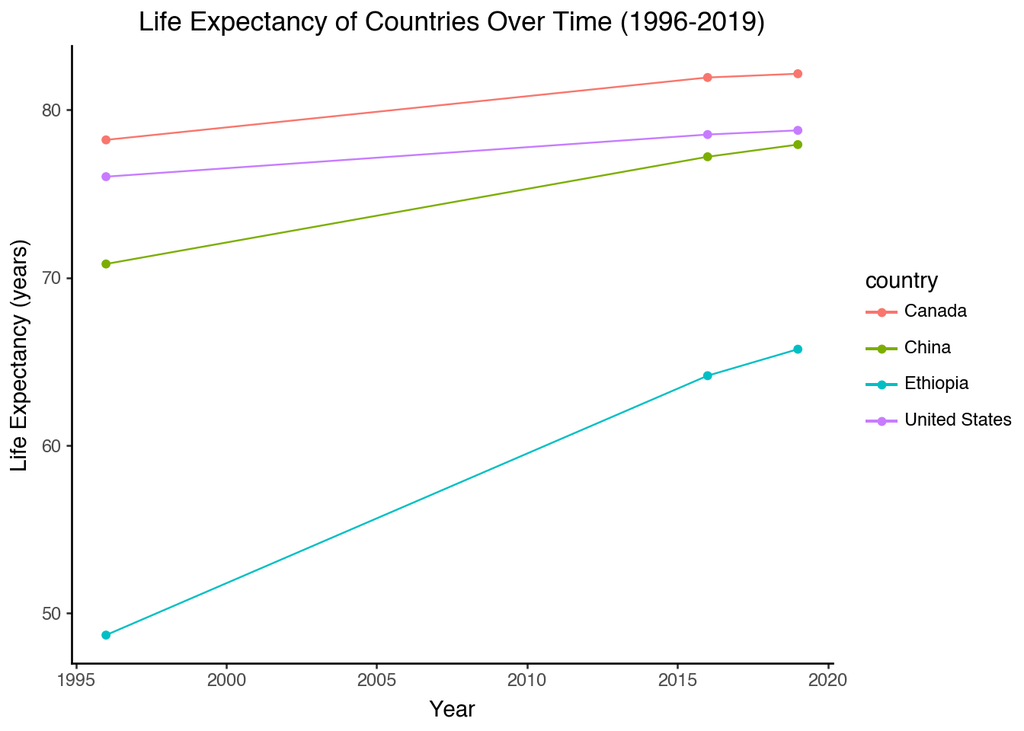

```python
# Line plot
# Canada + 3 contrasting countries
contrasts = ['Canada', 'United States', 'Ethiopia', 'China']
df_contrasts = df[df['country'].isin(contrasts)]

(
    ggplot(df_contrasts, aes(x='year', y='life_expectancy', color='country')) +
    geom_line() +
    geom_point() +
    labs(title='Life Expectancy of Countries Over Time (1996-2019)', x='Year', y='Life Expectancy (years)') +
    theme_classic()
)
```

#### Alcohol Consumption by Year

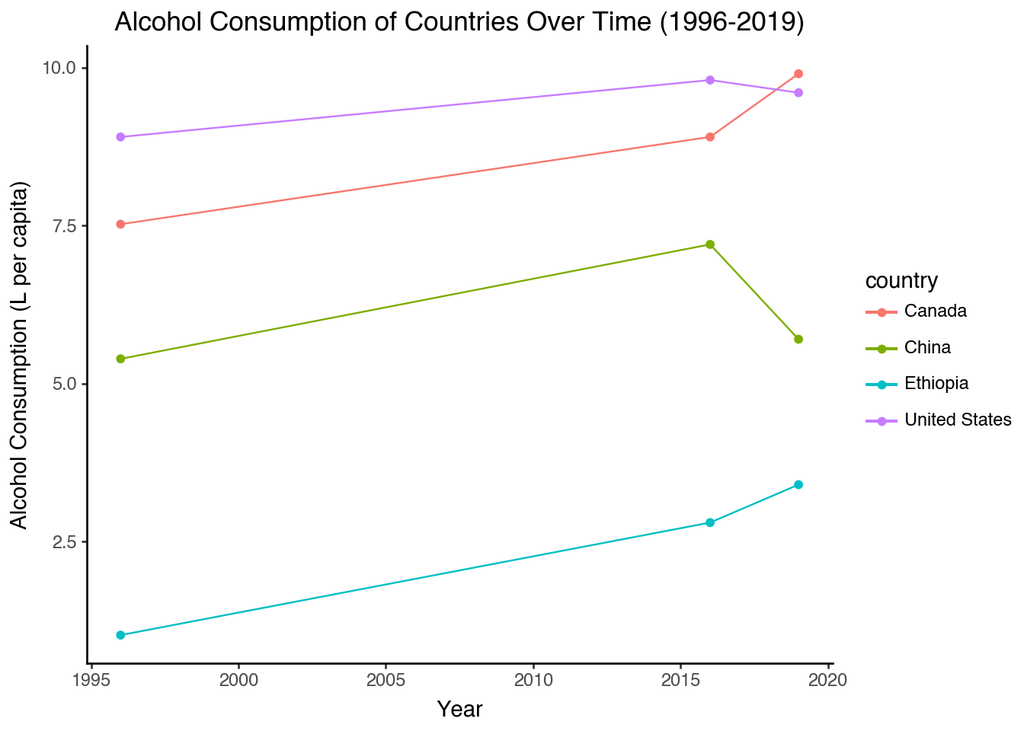

```python
# Line plot
# Canada + 3 contrasting countries
(
    ggplot(df_contrasts, aes(x='year', y='alcohol_consumption', color='country')) +
    geom_line() +
    geom_point() +
    labs(title='Alcohol Consumption of Countries Over Time (1996-2019)', x='Year', y='Alcohol Consumption (L per capita)') +
    theme_classic()
)
```

**Interpretation:**

- The first line plot shows the change in life expectancy of Canada, US, China, and Ethiopia between 1996 and 2019. All four lines show an increasing trend. The lines for Canada and US are largely comparable, but Canada has a slightly higher life expectancy at all three recorded time points. The discrepancy between the life expectancy in China and in Canada has reduced since 1996. For Ethiopia, the life expectancy increases from less than 50 to approximately 65 bewteen 1996 and 2019, which is substantial.
- The second line plot shows the change in alcohol consumption (litres per capita) in these four countries between 1996 and 2019. Again, Canada and US show comparable trends. US has the highest alcohol consumption up until 2019, when Canada’s consumption exceeded US’s value. China’s alcohol consumption increases between 1996 and 2016 and decreases sharply between 2016 and 2019. Ethiopia’s alcohol consumption has been monotonically increasing; however, it remains low compared to the other three countries in the plot.

### 4b. Faceted Scatterplots with Regression Lines

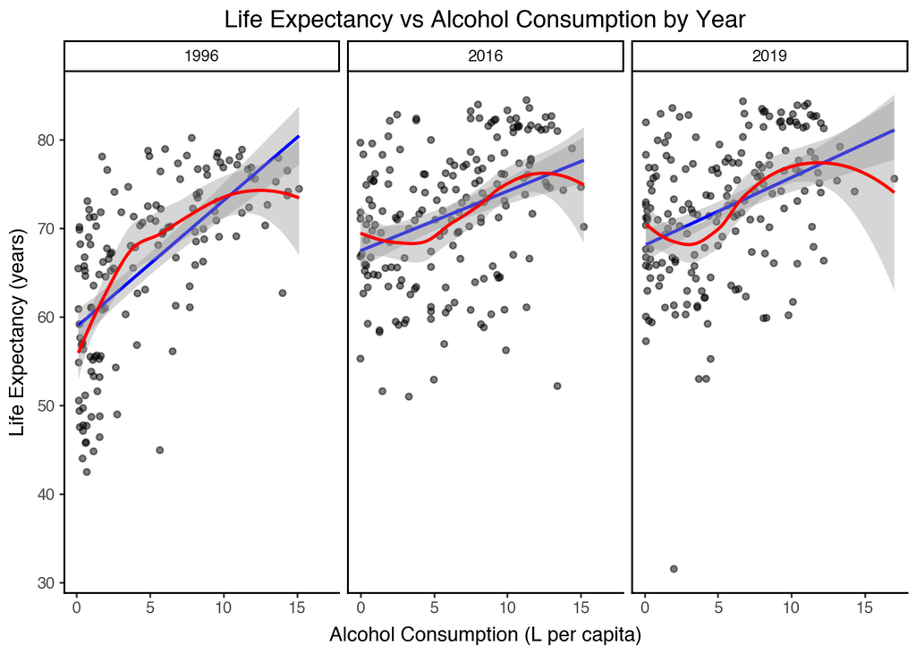

```python
# Facet plot by year (1996, 2016, 2019)
# Scatterplots of life expectancy vs alcohol consumption w linear and lowess regression lines
(
    ggplot(df.dropna(), aes(x='alcohol_consumption', y='life_expectancy')) +
    geom_point(alpha=0.5) +
    geom_smooth(method='lm', color='blue') +
    geom_smooth(method='loess', color='red') +
    facet_wrap('~year') +
    labs(x='Alcohol Consumption (L per capita)', y='Life Expectancy (years)',
         title='Life Expectancy vs Alcohol Consumption by Year') +
    theme_classic()
)
```

**Interpretation:**

- Overall, there is a weak to moderate positive association between alcohol consumption and life expectancy at all 3 time points (1996, 2016, 2019). Visually, the linear regression lines all have positive slopes. Temporally, the scatter shows an upward trend from 1996 compared to 2016 and 2019.
- The positive association does not imply causation and is likely confounded by variables like GDP, since GDP may explain both alcohol consumption and life expectancy.
- The Loess regression produced curves for all three scatterplots. The curve flattens/becomes concave down for high alcohol consumption values, indicating that the positive association diminishes once alcohol consumption exceeds a threshold.
- In all facets, the spread of points on the vertical axis (life expectancy) is wider for low alcohol consumption.

### 4c. Faceted Boxplots: Alcohol Consumption by GDP Level

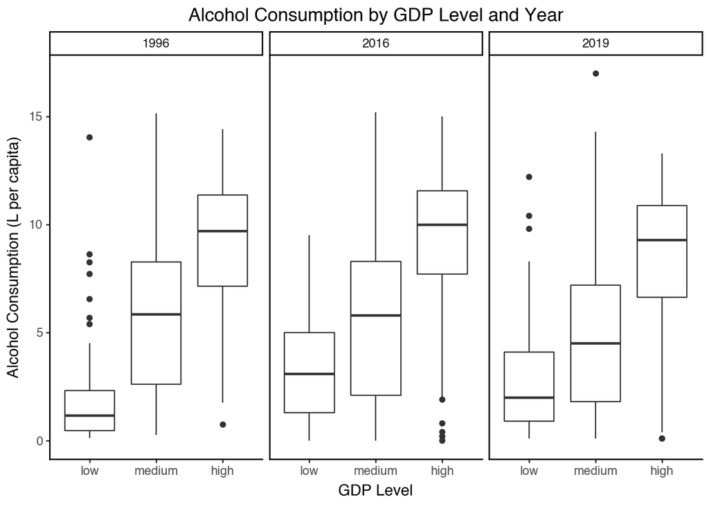

```python
# Facet plot by year (1996, 2016, 2019), boxplots of alcohol consumption by GDP level
(
    ggplot(df.dropna(), aes(x='gdp_level', y='alcohol_consumption')) +
    geom_boxplot() +
    facet_wrap('~year') +
    labs(x='GDP Level', y='Alcohol Consumption (L per capita)',
         title='Alcohol Consumption by GDP Level and Year') +
    theme_classic()
)
```

**Interpretation:**

- Overall, there is a positive association between GDP level and alcohol consumption at all 3 time points (1996, 2016, 2019). This is consistent with EDA results where many European countries have the highest alcohol consumption values.
- Low GDP countries have the lowest alcohol consumption, but there are some high outliers in the data for 1996 and 2019. High GDP countries have some low outliers, which can be explained by countries with a combination of economic prosperity and cultural conservativeness (e.g. Singapore).
- Temporally, the alcohol consumption for medium and high GDP levels is fairly stable. By contrast, between 1996 and 2016/19, the median alcohol consumption for low GDP countries approximately doubles.

### 4d. Barplot: Top 10 Countries by Change in Life Expectancy

#### Calculate Change

```python
# Top 10 countries with largest change in life expectancy
df_1996 = df[df['year'] == 1996][['country', 'life_expectancy']].rename(columns={'life_expectancy': 'le_1996'})
df_2019 = df[df['year'] == 2019][['country', 'life_expectancy']].rename(columns={'life_expectancy': 'le_2019'})

le_change = df_1996.merge(df_2019, on='country')
le_change['change'] = le_change['le_2019'] - le_change['le_1996']
top10 = le_change.nlargest(10, 'change')
display(top10)
```

|  | country | le_1996 | le_2019 | change |
| --- | --- | --- | --- | --- |
| 140 | Rwanda | 42.486 | 66.691 | 24.205 |
| 102 | Malawi | 44.005 | 64.995 | 20.990 |
| 175 | Uganda | 47.759 | 66.354 | 18.595 |
| 167 | Timor-Leste | 48.260 | 66.496 | 18.236 |
| 27 | Burundi | 44.807 | 62.180 | 17.373 |
| 186 | Zambia | 45.757 | 62.914 | 17.157 |
| 57 | Ethiopia | 48.697 | 65.741 | 17.044 |
| 4 | Angola | 46.418 | 63.051 | 16.633 |
| 97 | Liberia | 44.945 | 61.232 | 16.287 |
| 147 | Sierra Leone | 43.528 | 59.593 | 16.065 |

#### Create Barplot

|  | country | country_code | year | life_expectancy | population | gdp_per_capita | alcohol_consumption | gdp_level | change |
| --- | --- | --- | --- | --- | --- | --- | --- | --- | --- |
| 0 | Angola | AGO | 2019 | 63.051 | 32375632.0 | 2493.678844 | 6.20 | medium | 16.633 |
| 1 | Angola | AGO | 1996 | 46.418 | 14170973.0 | 531.115367 | 1.58 | low | 16.633 |
| 2 | Burundi | BDI | 2019 | 62.180 | 12255336.0 | 234.310616 | 4.10 | low | 17.373 |
| 3 | Burundi | BDI | 1996 | 44.807 | 6070506.0 | 143.156741 | 1.17 | low | 17.373 |
| 4 | Ethiopia | ETH | 2019 | 65.741 | 115737383.0 | 793.473247 | 3.40 | low | 17.044 |
| 5 | Ethiopia | ETH | 1996 | 48.697 | 59467635.0 | 147.327459 | 1.02 | low | 17.044 |
| 6 | Liberia | LBR | 2019 | 61.232 | 5043721.0 | 658.164181 | 3.60 | low | 16.287 |
| 7 | Liberia | LBR | 1996 | 44.945 | 2232289.0 | 71.406525 | 5.68 | low | 16.287 |
| 8 | Malawi | MWI | 2019 | 64.995 | 19025752.0 | 580.889140 | 3.20 | low | 20.990 |
| 9 | Malawi | MWI | 1996 | 44.005 | 10352228.0 | 320.662736 | 0.42 | low | 20.990 |
| 10 | Rwanda | RWA | 2019 | 66.691 | 12776103.0 | 810.051412 | 1.90 | low | 24.205 |
| 11 | Rwanda | RWA | 1996 | 42.486 | 6708764.0 | 206.049114 | 0.71 | low | 24.205 |
| 12 | Sierra Leone | SLE | 2019 | 59.593 | 7731991.0 | 843.712518 | 0.30 | low | 16.065 |
| 13 | Sierra Leone | SLE | 1996 | 43.528 | 4199210.0 | 224.258711 | NaN | low | 16.065 |
| 14 | Timor-Leste | TLS | 2019 | 66.496 | 1300945.0 | 1562.364581 | 0.40 | medium | 18.236 |
| 15 | Timor-Leste | TLS | 1996 | 48.260 | 892282.0 | 344.013328 | NaN | low | 18.236 |
| 16 | Uganda | UGA | 2019 | 66.354 | 42999637.0 | 822.171150 | 12.20 | low | 18.595 |
| 17 | Uganda | UGA | 1996 | 47.759 | 21231550.0 | 284.698259 | 0.46 | low | 18.595 |
| 18 | Zambia | ZMB | 2019 | 62.914 | 18513839.0 | 1258.986198 | 3.90 | low | 17.157 |
| 19 | Zambia | ZMB | 1996 | 45.757 | 9004053.0 | 399.511305 | 0.63 | low | 17.157 |

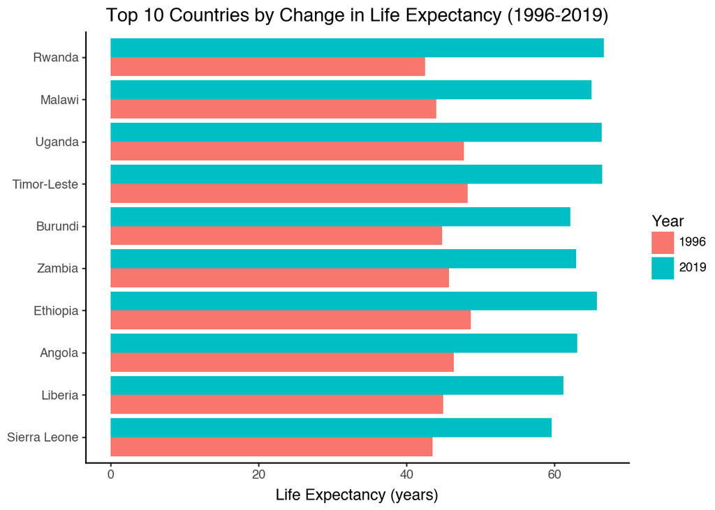

```python
# Barplot of life expectancy in 1996 and 2019 for the top 10 countries
top10_long = df[df['country'].isin(top10['country']) & df['year'].isin([1996, 2019])]
top10_long = top10_long.merge(top10[['country', 'change']], on='country')
display(top10_long)

(
    ggplot(top10_long, aes(x='reorder(country, change)', y='life_expectancy', fill='factor(year)')) +
    geom_col(position='dodge') +
    coord_flip() +
    labs(x='', y='Life Expectancy (years)', fill='Year',
         title='Top 10 Countries by Change in Life Expectancy (1996-2019)') +
    theme_classic()
)
```

**Interpretation:**

- Among the top 10 countries by change in life expectancy, 9 are in Africa, and 1 is in Asia. This makes sense because these countries had a low baseline life expectancy (< 50 years) in 1996 and then experienced improvement in public health. In 2019, the range of life expectancy for these 10 countries in roughly 60 to 65 years.
- By inspection, Rwanda had the largest increase in life expectancy of more than 20 years. Sierra Leone had the 10th largest increase in life expectancy of approximately 15 years.

### 4e. Custom Plot: Role of GDP in Alcohol-Life Expectancy Association

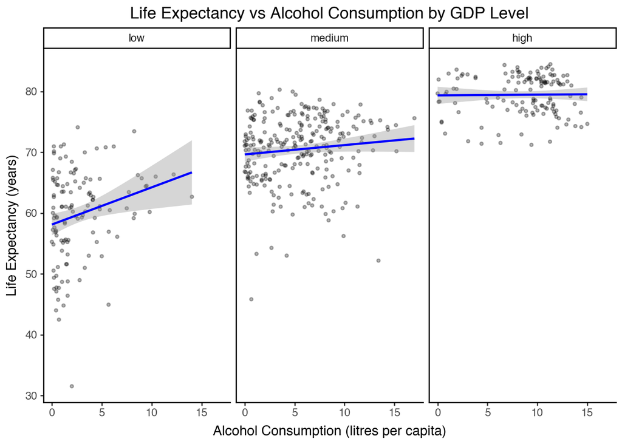

```python
# Faceted scatterplot by GDP level with linear regression line
(
    ggplot(df.dropna(), aes(x='alcohol_consumption', y='life_expectancy')) +
    geom_point(alpha=0.3, size=1) +
    geom_smooth(method='lm', color='blue') +
    facet_wrap('~gdp_level', ncol=3) +
    labs(
        title='Life Expectancy vs Alcohol Consumption by GDP Level',
        x='Alcohol Consumption (litres per capita)',
        y='Life Expectancy (years)'
    ) +
    theme_classic()
)
```

# Advanced Regression

## Question 5 (8 points)

### Linear Regression Model

```python
display(df["gdp_per_capita"].describe())
display(df["gdp_level"].value_counts())
```

```
count       556.000000
mean      11283.244066
std       16661.635359
min          71.406525
25%        1287.345659
50%        4125.174909
75%       13270.026950
max      112696.649060
Name: gdp_per_capita, dtype: float64
```

```
gdp_level
medium    278
low       139
high      139
Name: count, dtype: int64
```

```python
# Multiple linear regression: life expectancy ~ alcohol + GDP per capita + year
df_reg = df.dropna()

# We already have GDP per capita (GDP scaled by population)
X = df_reg[['alcohol_consumption', 'gdp_per_capita', 'year']]
X = sm.add_constant(X)
y = df_reg['life_expectancy']

lm_model = sm.OLS(y, X).fit()
```

### GAM Model

```python
# GAM model with smooths on GDP per capita and alcohol consumption

# s(0) = alcohol_consumption, s(1) = gdp_per_capita; year is kept linear
X_gam = df_reg[['alcohol_consumption', 'gdp_per_capita', 'year']].values
y_gam = df_reg['life_expectancy'].values

gam_model = LinearGAM(
    s(0, n_splines=20) +
    s(1, n_splines=20) +
    l(2)
).fit(X_gam, y_gam)
```

### Linear Model Summary

```python
display(lm_model.summary())
```

OLS Regression Results

| Dep. Variable: | life_expectancy | R-squared: | 0.484 |
| --- | --- | --- | --- |
| Model: | OLS | Adj. R-squared: | 0.481 |
| Method: | Least Squares | F-statistic: | 159.8 |
| Date: | Sat, 14 Feb 2026 | Prob (F-statistic): | 4.53e-73 |
| Time: | 17:58:38 | Log-Likelihood: | -1688.3 |
| No. Observations: | 515 | AIC: | 3385. |
| Df Residuals: | 511 | BIC: | 3401. |
| Df Model: | 3 |  |  |
| Covariance Type: | nonrobust |  |  |

|  | coef | std err | t | P>\|t\| | [0.025 | 0.975] |
| --- | --- | --- | --- | --- | --- | --- |
| const | -302.3428 | 59.436 | -5.087 | 0.000 | -419.111 | -185.574 |
| alcohol_consumption | 0.4912 | 0.076 | 6.488 | 0.000 | 0.342 | 0.640 |
| gdp_per_capita | 0.0003 | 1.85e-05 | 14.175 | 0.000 | 0.000 | 0.000 |
| year | 0.1823 | 0.030 | 6.166 | 0.000 | 0.124 | 0.240 |

| Omnibus: | 89.134 | Durbin-Watson: | 0.900 |
| --- | --- | --- | --- |
| Prob(Omnibus): | 0.000 | Jarque-Bera (JB): | 153.232 |
| Skew: | -1.033 | Prob(JB): | 5.32e-34 |
| Kurtosis: | 4.694 | Cond. No. | 4.34e+06 |

Notes:  
[1] Standard Errors assume that the covariance matrix of the errors is correctly specified.  
[2] The condition number is large, 4.34e+06. This might indicate that there are  
strong multicollinearity or other numerical problems.

**Overall model fit:** The R-squared is 0.484, so 48% of the variance in life expectancy is explained by alcohol consumption, GDP per capita, and year. The adjusted R-squared is 0.481. The condition number is very high so we likely have multicollinearity.

**Interpretation of parameter estimates:** - All predictors are significant at the 0.001 level.

- The estimated coefficient for alcohol consumption is 0.4912. So the estimated mean increase in life expectancy for each litre per capita increase in alcohol consumption is approximately 0.49 years, holding GDP and year constant.
- Similarly, the estimated mean increase in life expectancy per unit increase in GDP per capita is 0.0003, holding other predictors constant. This may seem like a small effect, but that’s because GDP’s range is huge.

### GAM Summary

```python
display(gam_model.summary())
```

```
LinearGAM
=============================================== ==========================================================
Distribution:                        NormalDist Effective DoF:                                     22.4196
Link Function:                     IdentityLink Log Likelihood:                                 -1553.8442
Number of Samples:                          515 AIC:                                             3154.5277
                                                AICc:                                            3156.8592
                                                GCV:                                               27.6952
                                                Scale:                                              5.0531
                                                Pseudo R-Squared:                                   0.6942
==========================================================================================================
Feature Function                  Lambda               Rank         EDoF         P > x        Sig. Code
================================= ==================== ============ ============ ============ ============
s(0)                              [0.6]                20           12.4         9.90e-01
s(1)                              [0.6]                20           9.0          1.11e-16     ***
l(2)                              [0.6]                1            1.0          2.47e-03     **
intercept                                              1            0.0          1.38e-01
==========================================================================================================
Significance codes:  0 '***' 0.001 '**' 0.01 '*' 0.05 '.' 0.1 ' ' 1

WARNING: Fitting splines and a linear function to a feature introduces a model identifiability problem
         which can cause p-values to appear significant when they are not.

WARNING: p-values calculated in this manner behave correctly for un-penalized models or models with
         known smoothing parameters, but when smoothing parameters have been estimated, the p-values
         are typically lower than they should be, meaning that the tests reject the null too readily.
```

```
None
```

**Overall model fit:** - The pseudo R-squared is 0.6942. This is larger than R-squared given by the linear model, which is numerical evidence that the smooth terms capture meaningful nonlinearity.

**Interpretation of parameter estimates:** - The EDoF for alcohol consumption is 12.4; the EDoF for GDP per capita is 9. They are both substantially greater than 1, which suggest that the model learned curves and wiggly patterns for these two predictors.

- The smooth for GDP per capita is significant (p = 1.11e-16). The line for year is significant (p=2.47e-03). By comparison, the smooth for alcohol consumption is not significant.

### Plot GAM Smoothed Terms

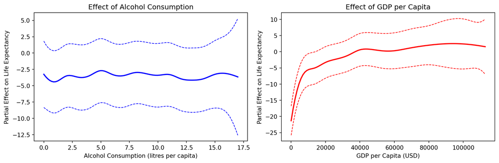

```python
# Plot partial dependence curves for each smooth predictor
fig, axes = plt.subplots(1, 2, figsize=(12, 4))

spec = [
    (0, 0, "Alcohol Consumption (litres per capita)", "blue", "Effect of Alcohol Consumption"),
    (1, 1, "GDP per Capita (USD)", "red", "Effect of GDP per Capita"),
]

for ax, (term, xcol, xlabel, color, title) in zip(axes, spec):
    XX = gam_model.generate_X_grid(term=term)
    x = XX[:, xcol]
    pd_effect = gam_model.partial_dependence(term=term, X=XX)
    _, ci = gam_model.partial_dependence(term=term, X=XX, width=0.95)

    ax.plot(x, pd_effect, color=color, lw=2)
    ax.plot(x, ci, color=color, ls="--", lw=1)
    ax.set(xlabel=xlabel, ylabel="Partial Effect on Life Expectancy", title=title)

plt.tight_layout()
plt.show()
```

**Interpretation:** - The left PDP is for the partial effect of alcohol consumption. The curve has wiggles but is mostly flat. The 95% CI is wide and grows further at extremely high values of alcohol consumption. From the GAM summary, we saw that the smooth term for alcohol is not significant, after controlling for GDP per capita and year. The visualization is aligned with that result.

- The right PDP is for the partial effect of GDP per capita. This is a curve that increases sharply from 0 to approximately $20000 and then flattens. The 95% CI grows as the x-axis increases. We can interpret the plot by saying GDP per capita has a strong positive effect on life expectancy, until it reaches a threshold. Comparing these two plots, GDP per capita is the stronger predictor.